# Run Operating Model

E Holmes

2020-05-25

The simulation functions are

- `SimulateWorld()` Use `?SimulateWorld` to read documentation
- `SimulateWorld_ROMS()`
- `SimulateWorld_ROMS_TrophicInteraction()`

## Run simulation

### Use `SimulateWorld()`

First load the **WRAP** library.

```r
library(WRAP)
```

This function simulates presence and abundance using a simulated temperature field. Parameters for the function are

- `abund_enviro` can be “lnorm_low” (SB); “lnorm_high” (EW); or “poisson” (JS).
- `PA_shape` can be “logistic” (SB); “logistic_prev”,“linear” (JS)
- `temp_spatial` can be “simple” (SB); or “matern” (EW)
- `temp_diff` is only for the simulated temperature. It specifies min and max temps at year 1 and year 100 (e.g. temp_diff=c(1,3,5,7) means year 1 varies from 1-3C and year 100 from 5-7C).

The defaults are `temp_diff = c(1, 3, 5, 7)`, `temp_spatial = "simple"`, `PA_shape = "logistic"`, and `abund_enviro = "lnorm_low"`. You can also set number of years, grid size, and start year.

```r
sim <- SimulateWorld()
```

`sim` (the output from a simulation function) is class “OM” and is a list. It has the simulated grid in `grid` and information about the simulation in `meta`. Typing the name of the output will print basic information about the simulation.

```r
sim
## Simulated species abundance and suitability from WRAP version 1.5 and function SimulateWorld
##    covariates: temp
##    grid.dimensions: 20, 20, 400 (nrow, ncol, cells)
##    grid.resolution 1, 1 (x, y)
##    grid.extent 1, 20, 1, 20 (xmin, xmax, ymin, ymax)
##    grid.units: not applicable
##    time.extent: 2001 to 2100 year
```

### Save data

Since simulations take a long time to run, you may want to create a directory in your working directory for the simulations and save them there. Then you can reload the simulations instead of re-running.

Create a directory for the simulations:

```r
if(!dir.exists(file.path(here::here(), 'Sim1')))
  dir.create(file.path(here::here(), 'Sim1'))
```

Save the simulation.

```r
saveRDS(sim, file=file.path(here::here(), "Sim1", "Sim.rds"))
```

## Plot

Plot time-series of total catch in observed years

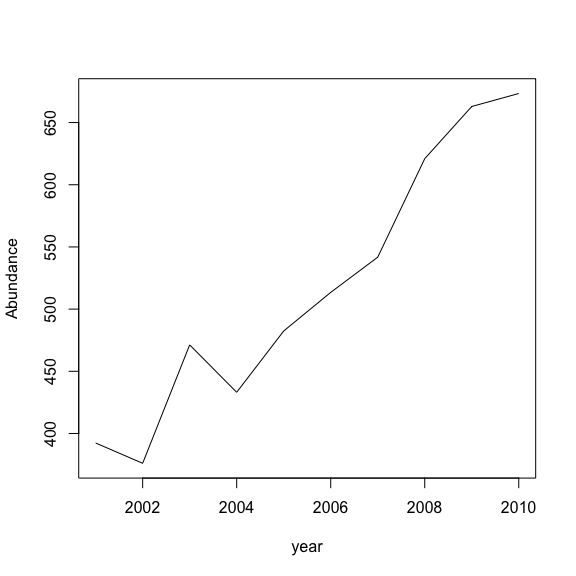

```r
data <- sim$grid
plot(aggregate(abundance~year, data[data$year<=2010,], FUN="sum"),type="l",ylab="Abundance")
```

plot time-series of total catch in forecast years

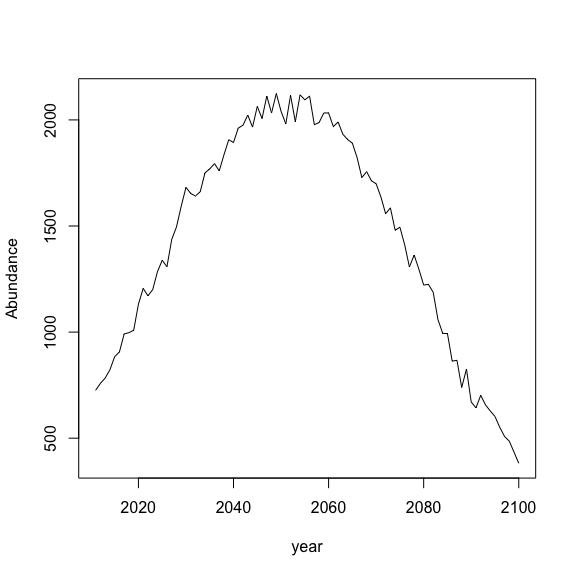

```r
data <- sim$grid
plot(aggregate(abundance~year,data[data$year>2010,], FUN="sum"),type="l", ylab="Abundance")
```

## Plot the abundance

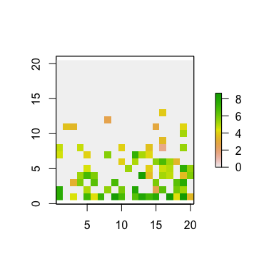

```r
library(raster)
df <- subset(sim$grid, year==2001)
df <- df[, c("lon", "lat", "abundance")]
dfr <- raster::rasterFromXYZ(df)
plot(dfr)
```

Show 4 years and remove the box and legend.

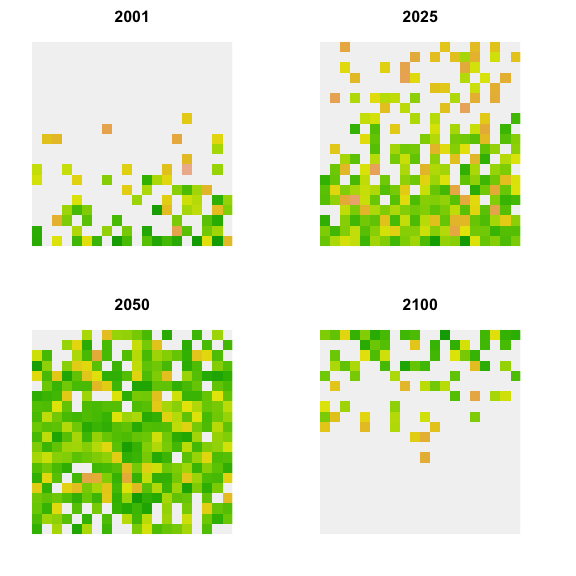

```r
library(raster)
par(mfrow=c(2,2), mar=c(2,2,2,2))
for(yr in c(2001, 2025, 2050, 2100)){
df <- subset(sim$grid, year==yr)
df <- df[, c("lon", "lat", "abundance")]
dfr <- raster::rasterFromXYZ(df)
plot(dfr, axes=FALSE, box=FALSE, legend=FALSE)
title(yr)
}
```